# Cellulose Morphology Counts

John Akwei, ECMp ERMp Data Scientist

Wednesday, October 07, 2015

[figure not shown]

## Synopsis

This document is a presentation of data, (Morphology Counts), in a visual format.

The Morphology Counts experiment involves extracting intestines of termites, containing different types of treatments (antibiotics), and plating them on selective media to see if bacteria grows.

There are 4 digits for the plate ID. The first letter indicates the media it was grown on. C stands for cellulose selective media. L stands for lignin selective media and A stands for actinomycete selective media, (bacteria that is specific to that media). I.e specific to lignin should only grow on the lignin media.

The next digit represents the treatment that was given to the termites that were extracted and plated. C = control, A = ampicillin, R= rifampicin, S = streptomycin. The 3rd digit represents the repeat number. There are 6 repeats of each treatment. The 4th digit represents the jar number. There are 3 jars per repeat. In summary, there are 6 repeats per treatment, and 4 treatments per selective media.

Morphology Type identifies 35 types of bacteria that were visually identified. This document includes all R coding, (for reproducible research).

#### Required R coding packages

```r
library(ggplot2)
library(plotrix)
```

#### Import of the Morphology Data

```r
dt <- read.csv("Morphotypes_of_all_media.csv")
dt2 <- read.csv("New_Cellulose_Morphology_Counts.csv")
```

#### Subsetting the Morphology Data

```r
morphotypes <- dt2[5:39]
write.csv(morphotypes, file="morphotypes.csv")
morph.average <- colMeans(morphotypes, na.rm=T)
ControlAve <- colMeans(morphotypes[1:17,], na.rm=T)
write.csv(ControlAve, file="ControlAveData.csv")
AmpicillinAve <- colMeans(morphotypes[18:35,], na.rm=T)
write.csv(AmpicillinAve, file="AmpicillinAveData.csv")
RifampicinAve <- colMeans(morphotypes[36:53,], na.rm=T)
write.csv(RifampicinAve, file="RifampicinAveData.csv")
StreptomycinAve <- colMeans(morphotypes[54:72,], na.rm=T)
write.csv(StreptomycinAve, file="StreptomycinAveData.csv")
```

## Morphology Results Pie Charts

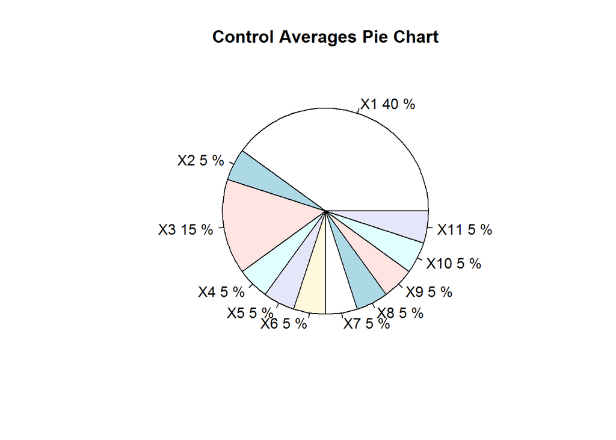

```r
slices <- table(ControlAve)
pct <- round(slices/sum(slices)*100)
lbls <- paste(names(dt2[5:39]), sep=" ", pct, "%")
pie(slices, labels=lbls, main="Control Averages Pie Chart")
```

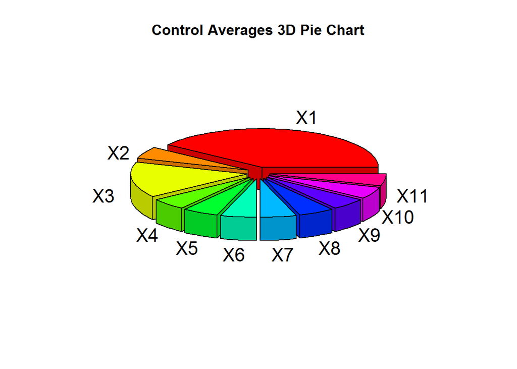

```r
lbls <- c("X1", "X2", "X3", "X4", "X5", "X6", "X7", "X8", "X9", "X10", "X11")
pie3D(slices,labels=lbls,explode=0.1, main="Control Averages 3D Pie Chart")
```

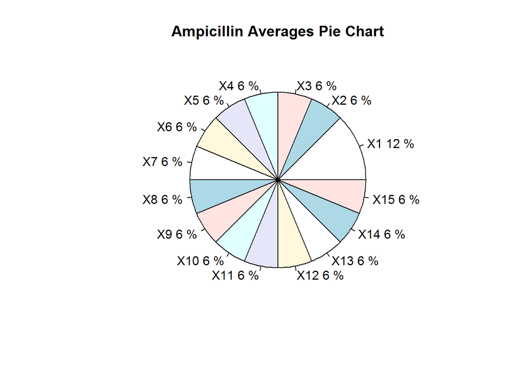

```r
slices <- table(AmpicillinAve)
pct <- round(slices/sum(slices)*100)
lbls <- paste(names(dt2[5:39]), sep=" ", pct, "%")
pie(slices, labels=lbls, main="Ampicillin Averages Pie Chart")
```

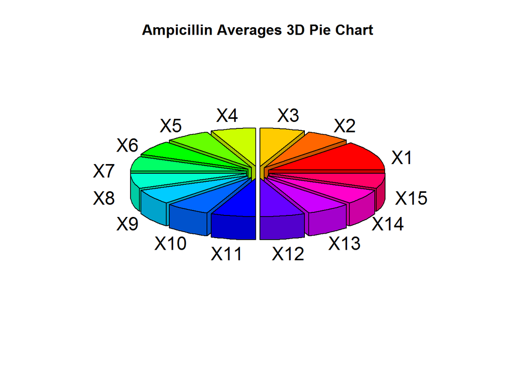

```r
lbls <- c("X1", "X2", "X3", "X4", "X5", "X6", "X7", "X8", "X9", "X10", "X11", "X12", "X13", "X14", "X15")
pie3D(slices,labels=lbls,explode=0.1, main="Ampicillin Averages 3D Pie Chart")
```

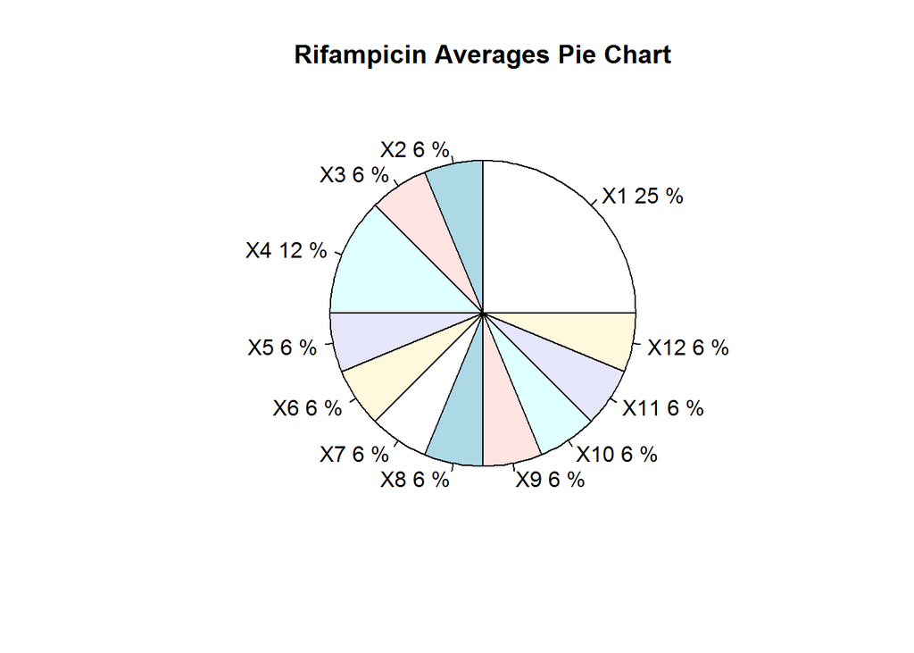

```r
slices <- table(RifampicinAve)
pct <- round(slices/sum(slices)*100)
lbls <- paste(names(dt2[5:39]), sep=" ", pct, "%")
pie(slices, labels=lbls, main="Rifampicin Averages Pie Chart")
```

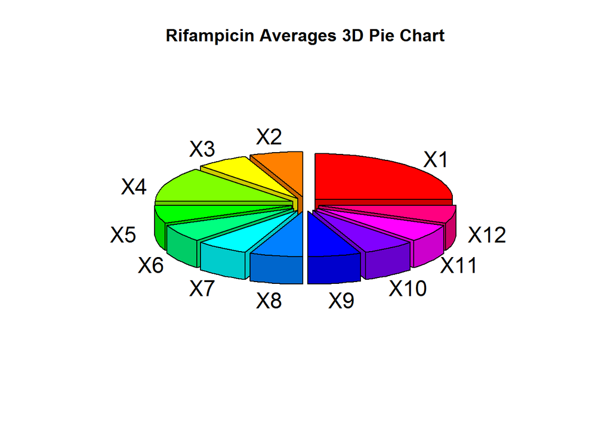

```r
lbls <- c("X1", "X2", "X3", "X4", "X5", "X6", "X7", "X8", "X9", "X10", "X11", "X12")
pie3D(slices,labels=lbls,explode=0.1, main="Rifampicin Averages 3D Pie Chart")
```

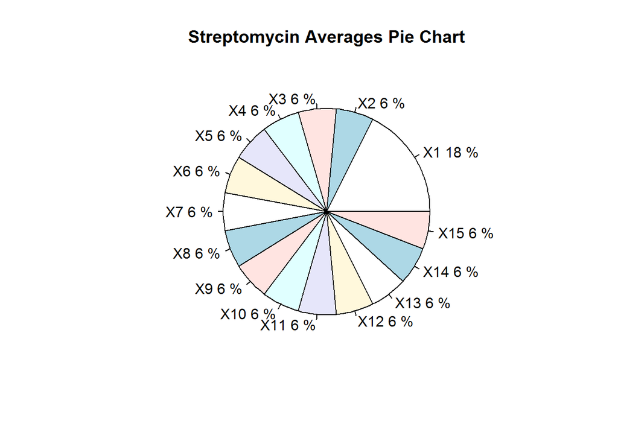

```r
slices <- table(StreptomycinAve)
pct <- round(slices/sum(slices)*100)
lbls <- paste(names(dt2[5:39]), sep=" ", pct, "%")
pie(slices, labels=lbls, main="Streptomycin Averages Pie Chart")
```

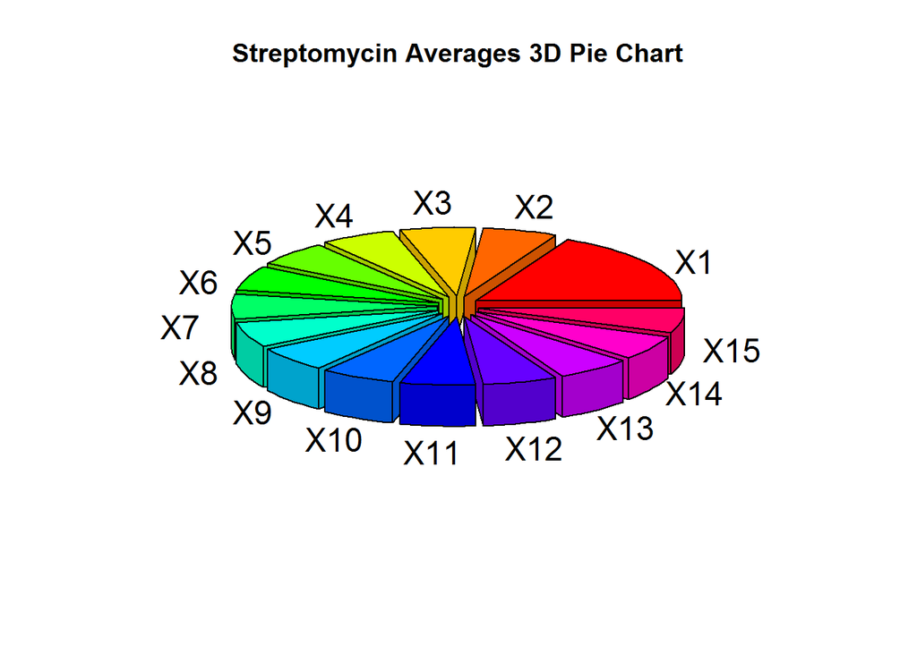

```r
lbls <- c("X1", "X2", "X3", "X4", "X5", "X6", "X7", "X8", "X9", "X10", "X11", "X12", "X13", "X14", "X15")
pie3D(slices,labels=lbls,explode=0.1, main="Streptomycin Averages 3D Pie Chart")
```

## Other Pie Charts of Morphology Experimental Data

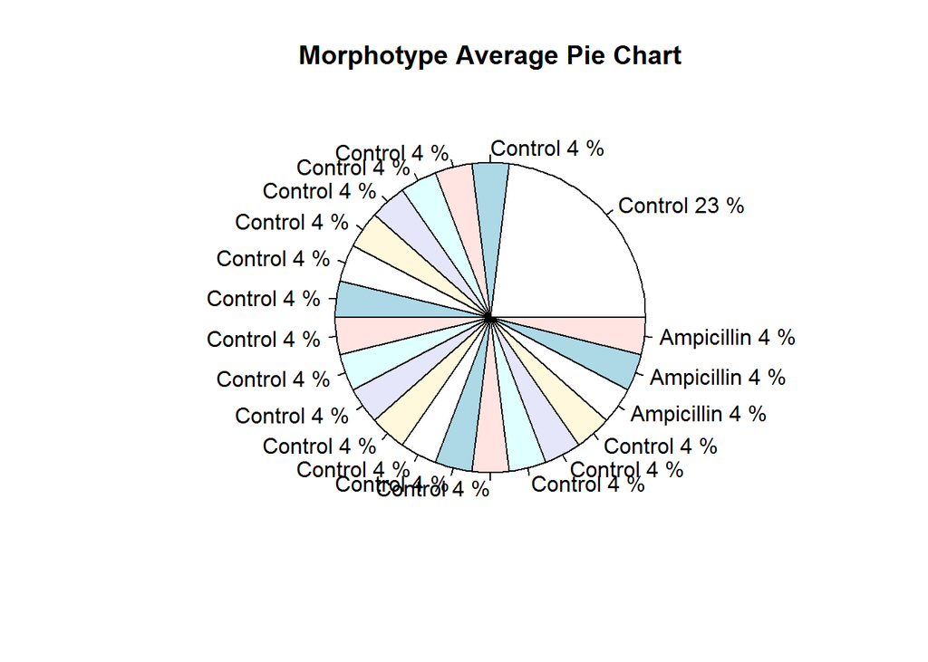

```r
slices <- table(morph.average)
pct <- round(slices/sum(slices)*100)
lbls <- paste(dt2$Treatment, sep=" ", pct, "%")
pie(slices, labels=lbls, main="Morphotype Average Pie Chart")
```

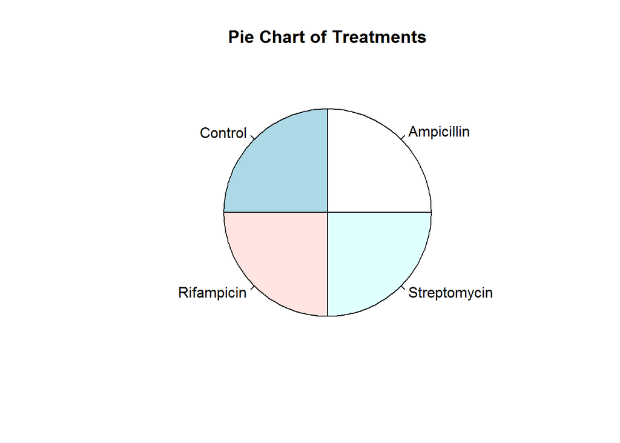

```r
slices <- table(dt2$Treatment)
lbls <- paste(names(slices))
# lbls <- paste(names(slices), "\n", slices, sep="")
pie(slices, labels=lbls, main="Pie Chart of Treatments")
```

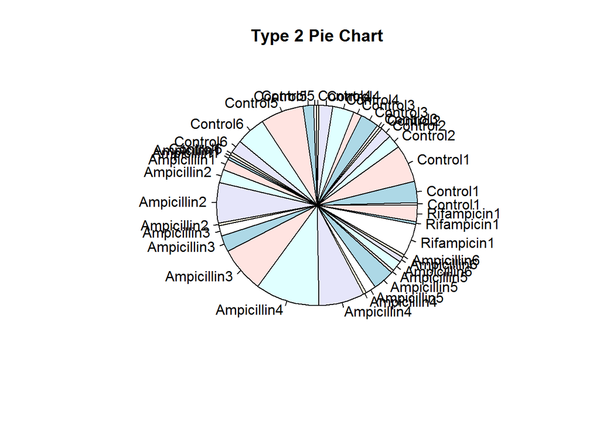

```r
slices <- na.omit(dt2$X2)
lbls <- paste(dt2$Treatment, sep="", dt2$Jar)
pie(slices, labels = lbls, main="Type 2 Pie Chart")
```

## Bar Charts of Morphology Experiment Data

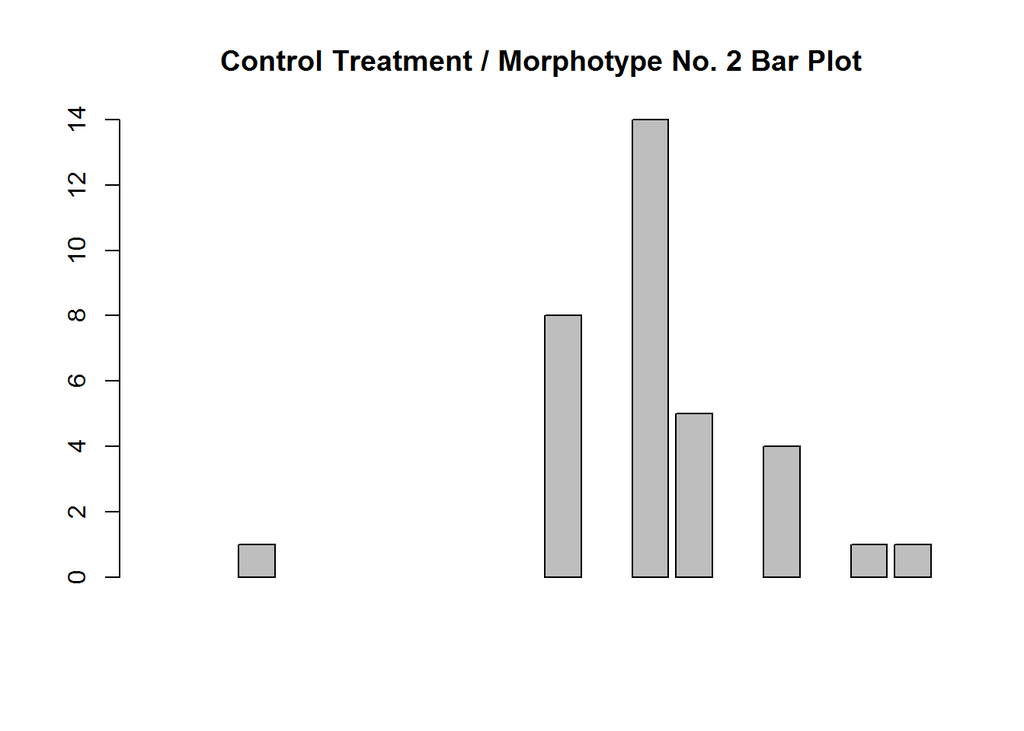

```r
Category1 <- dt2$X2[dt2$Treatment=="Control"]
barplot(Category1, main="Control Treatment / Morphotype No. 2 Bar Plot")
```

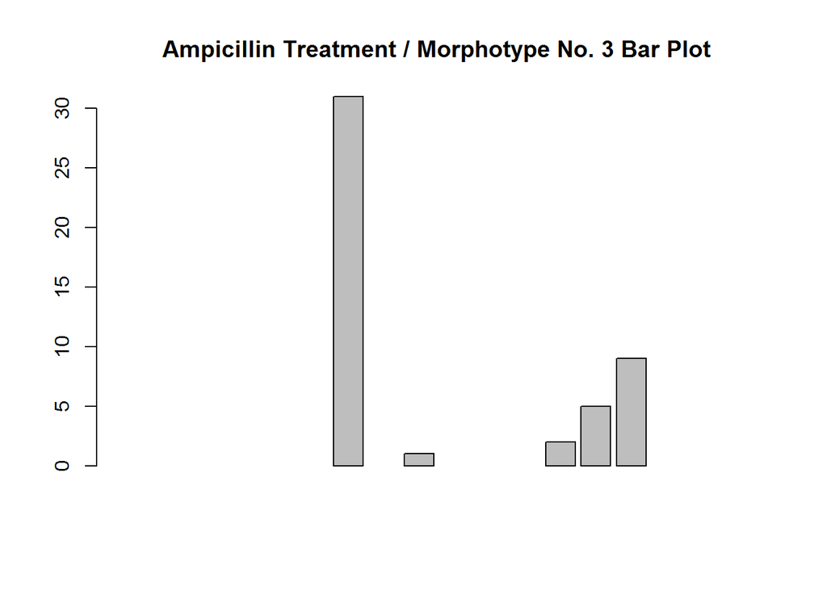

```r
Category2 <- dt2$X3[dt2$Treatment=="Ampicillin"]
barplot(Category2, main="Ampicillin Treatment / Morphotype No. 3 Bar Plot")
```

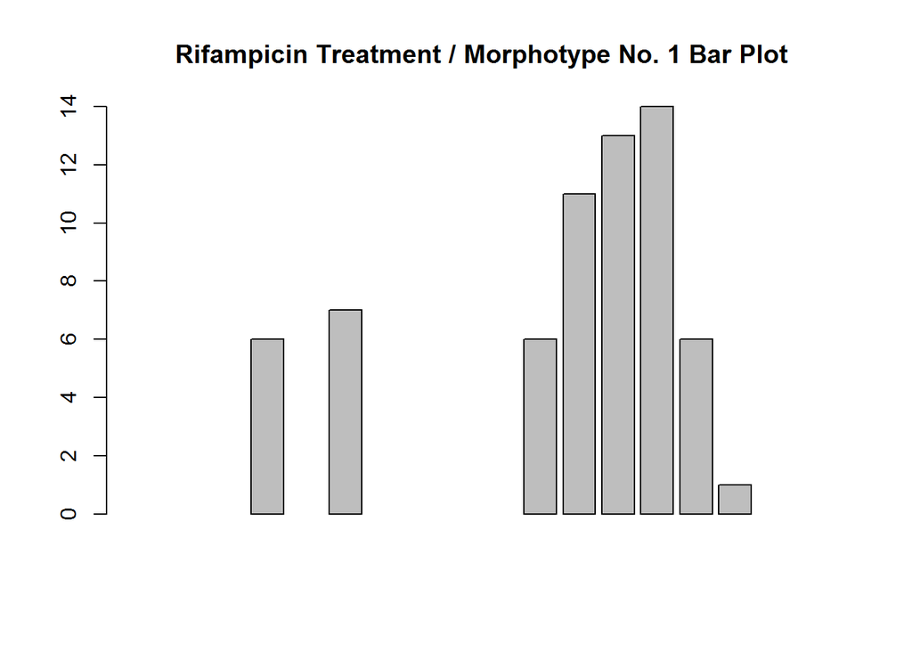

```r
Category3 <- dt2$X1[dt2$Treatment=="Rifampicin"]
barplot(Category3, main="Rifampicin Treatment / Morphotype No. 1 Bar Plot")
```

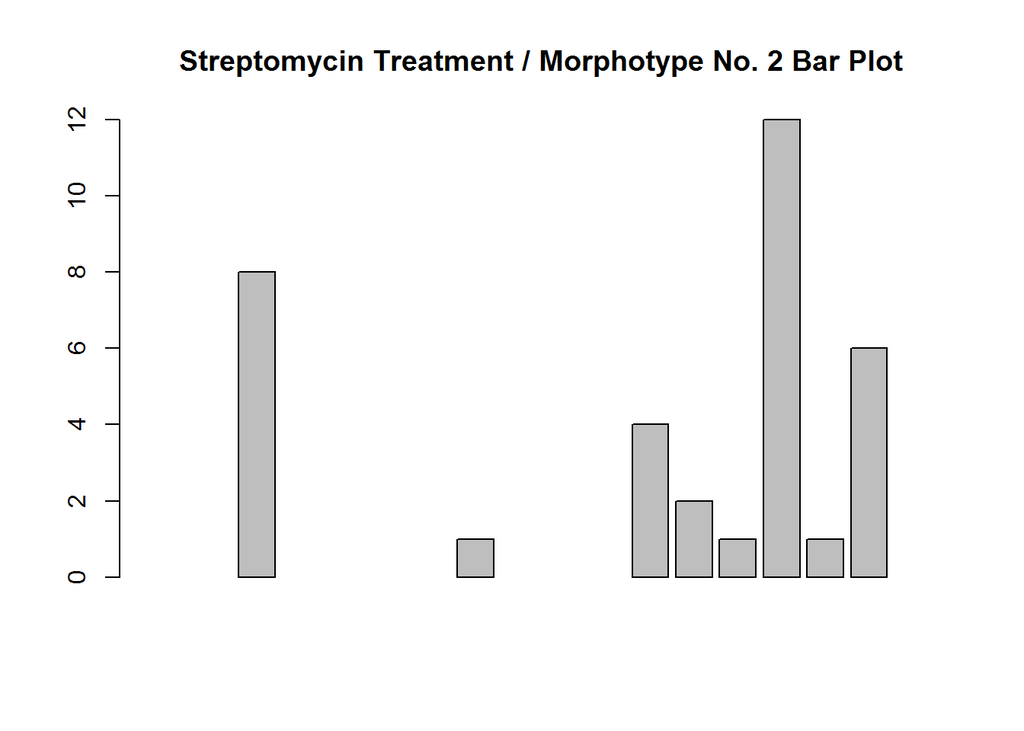

```r
Category4 <- dt2$X2[dt2$Treatment=="Streptomycin"]
barplot(Category4, main="Streptomycin Treatment / Morphotype No. 2 Bar Plot")
```